# STATS506-HW2-JunjieZeng

Author

JunjieZeng

# STATS506 Problem Set #2

## Repository

https://github.com/JunjieZeng1/STATS-506.git

## Problem 1 Dice Game

### a

Version 1

```r
#' Function to simulate dice game using a loop
#'
#' @param x a numeric number, the number of dice to roll
#' @return Total winnings
play_dice_loop <- function(x){
  net_win = 0

  for (i in 1:x){
    roll <- sample(c(1:6), size = 1)
    if (roll %in% c(3, 5)){
      net_win = net_win + 2 * roll - 2
    }
    else{
      net_win = net_win - 2
    }
  }
  return(net_win)
}
```

Version2

```r
#' Function to simulate dice game using built-in R vectorized functions
#'
#' @param x a numeric number, the number of dice to roll
#' @return Total winnings
play_dice_vec <- function(x){
  roll <- sample(c(1:6), x, replace = TRUE)
  games <- ifelse(roll %in% c(3, 5), roll * 2 - 2 , -2)
  net_win = sum(games)
  return(net_win)
}
```

Version3

```r
#' Function to simulate dice game using table()
#'
#' @param x a numeric number, the number of dice to roll
#' @return Total winnings
play_dice_tb <- function(x){
  net_win = 0
  roll <- sample(c(1:6), x, replace = TRUE)
  table_roll <- table(roll)
  if ("3" %in% names(table_roll)){
    num_3 = as.integer(table_roll["3"])
    net_win = net_win +  2 * 3 * num_3
  }

  if ("5" %in% names(table_roll)){
    num_5 = as.integer(table_roll["5"])
    net_win = net_win +  2 * 5 * num_5
  }

  net_win = net_win - 2 * x

  return(net_win)
}
```

Version4

```r
#' Function to simulate dice game using apply
#'
#' @param x a numeric number, the number of dice to roll
#' @return Total winnings

play_dice_apply <- function(x){
  roll <- sample(c(1:6), x, replace = TRUE)
  games <- sapply(roll, function(x){
    if (x %in% c(3, 5)){
      num = x * 2 - 2
      return(num)
    }
    else{
      return(-2)
    }
  })
  return(sum(games))
}
```

### b

```r
for (i in c(3, 3000)){
  print(paste('Using loop with', i, 'rolls:', play_dice_loop(i)))
  print(paste('Using vectorized function with', i, 'rolls:', play_dice_vec(i)))
  print(paste('Using table with', i, 'rolls:', play_dice_tb(i)))
  print(paste('Using sapply with', i, 'rolls:', play_dice_apply(i)))
}
```

```
[1] "Using loop with 3 rolls: -6"
[1] "Using vectorized function with 3 rolls: -6"
[1] "Using table with 3 rolls: 0"
[1] "Using sapply with 3 rolls: 4"
[1] "Using loop with 3000 rolls: 2066"
[1] "Using vectorized function with 3000 rolls: 2112"
[1] "Using table with 3000 rolls: 1812"
[1] "Using sapply with 3000 rolls: 2592"
```

### c

```r
for (i in c(3, 3000)){
  set.seed(506)
  print(paste('Using loop with', i, 'rolls:', play_dice_loop(i)))
  set.seed(506)
  print(paste('Using vectorized function with', i, 'rolls:', play_dice_vec(i)))
  set.seed(506)
  print(paste('Using table with', i, 'rolls:', play_dice_tb(i)))
  set.seed(506)
  print(paste('Using sapply with', i, 'rolls:', play_dice_apply(i)))
}
```

```
[1] "Using loop with 3 rolls: 6"
[1] "Using vectorized function with 3 rolls: 6"
[1] "Using table with 3 rolls: 6"
[1] "Using sapply with 3 rolls: 6"
[1] "Using loop with 3000 rolls: 1974"
[1] "Using vectorized function with 3000 rolls: 1974"
[1] "Using table with 3000 rolls: 1974"
[1] "Using sapply with 3000 rolls: 1974"
```

We see that all the four versions give the same result for a given number of rolls. So those four versions are the same.

### d

```r
library(microbenchmark)
```

```r
microbenchmark(play_dice_loop(1000), play_dice_vec(1000), play_dice_tb(1000), play_dice_apply(1000))
```

```
Unit: microseconds
                  expr      min        lq      mean    median        uq
  play_dice_loop(1000) 3792.626 3847.5215 4263.5403 3908.3760 4200.7300
   play_dice_vec(1000)  188.459  192.6255  204.8191  199.6675  214.2510
    play_dice_tb(1000)  143.126  152.6675  190.9445  173.3965  230.5005
 play_dice_apply(1000) 1280.542 1302.0425 1368.3320 1313.2715 1334.1050
      max neval
 9096.042   100
  245.584   100
  272.209   100
 3844.001   100
```

```r
microbenchmark(play_dice_loop(100000), play_dice_vec(100000), play_dice_tb(100000), play_dice_apply(100000))
```

```
Unit: milliseconds
                   expr        min         lq       mean     median        uq
  play_dice_loop(1e+05) 408.136625 425.792375 447.430930 438.679001 463.20538
   play_dice_vec(1e+05)  17.556667  17.721355  18.329129  17.958875  18.63821
    play_dice_tb(1e+05)   7.312251   7.552583   8.006031   7.695626   8.28298
 play_dice_apply(1e+05) 137.506543 148.266355 163.383109 159.901458 173.05086
       max neval
 523.81442   100
  24.82492   100
  10.70321   100
 213.59050   100
```

The first table with input(1000) has unit in microseconds.The second table with input(100000) has unit in milliseconds. In both tables, we see the speed rank as follows: play_dice_tb > play_dice_vec >> play_dice_apply >> play_dice_loop. This is especially significant when input is large.

### e

```r
set.seed(506)
play_dice_tb(100000)
```

```
[1] 67796
```

Based on a Monte Carlo simulation with 100000 runs, the final net gain is 67796, suggesting this is a unfair game.

## Problem 2 Linear Regression

### a

```r
# Load data
data <- read.csv("/Users/junjiezeng/Desktop/git/STATS506/HW2/cars.csv")
```

```r
# Change column names
colnames(data) <- c("Dim:Height",
                    "Dim:Length",
                    "Dim:Width",
                    "EI:Driveline",
                    "EI:Engine_type",
                    "EI:Hybrid",
                    "EI:Num_f_gears",
                    "EI:Transmission",
                    "FI:City_mpg",
                    "FI:Fuel_type",
                    "FI:Highway_mpg",
                    "ID:Class",
                    "ID:ID",
                    "ID:Make",
                    "ID:Model_year",
                    "ID:Year",
                    "EI:ES_horsepower",
                    "EI:ES_torque")
```

### b

```r
# Restrict the data to cars whose Fuel Type is “Gasoline”
data1 <- data[data$`FI:Fuel_type` == 'Gasoline', ]
```

### c

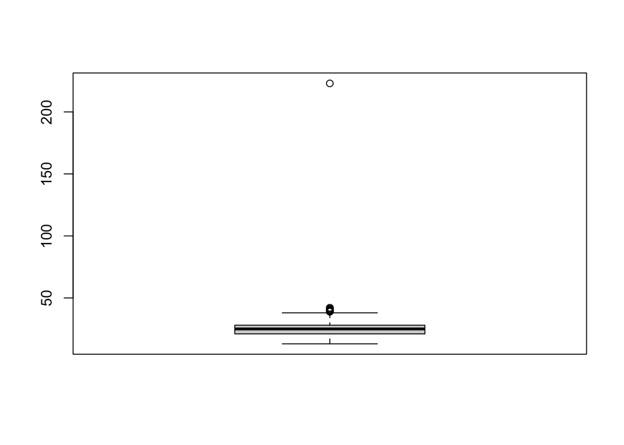

```r
# Create a boxplot
boxplot(data1$`FI:Highway_mpg`)
```

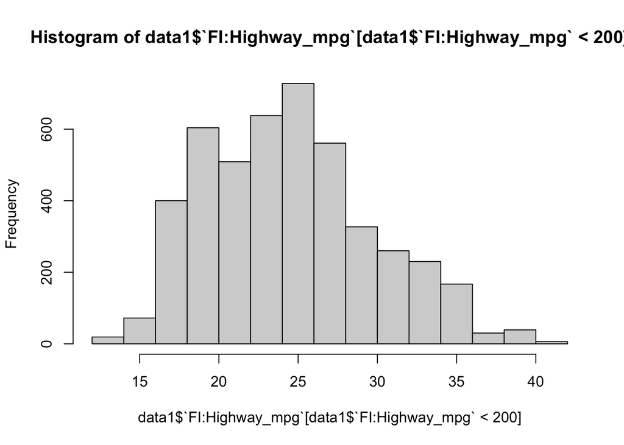

```r
# Remove the largest outlier to show the grpah
hist(data1$`FI:Highway_mpg`[data1$`FI:Highway_mpg` < 200])
```

We see the graph is right skewed, so we better do a log-transformation on our data.

```r
# Create a new variable with log-transformation on highway mpg
data1['log_highway_mpg'] <- log(data1$`FI:Highway_mpg`)
```

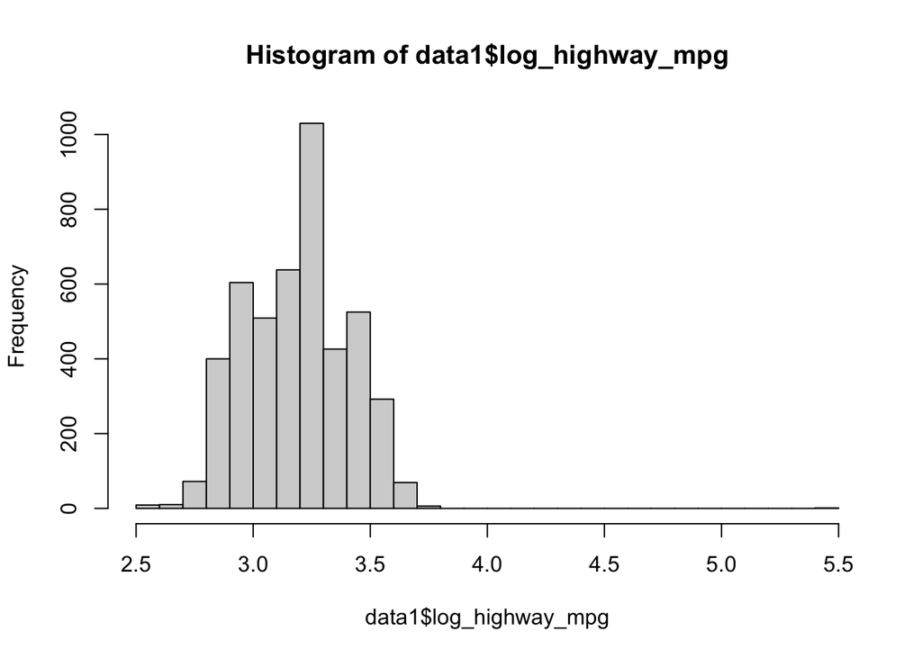

```r
# Look at the distribution of log highway mpg
hist(data1$log_highway_mpg, nclass = 30)
```

We see it looks more symmetrical except the large ourlier at 5.5.

### d

```r
# Linear regression model
lm1 <- lm(log_highway_mpg ~ `EI:ES_torque` + as.factor(`ID:Year`) + `EI:ES_horsepower` + `Dim:Height` + `Dim:Length` + `Dim:Width`,data = data1)

# Summary of the model
summary(lm1)
```

```
Call:
lm(formula = log_highway_mpg ~ `EI:ES_torque` + as.factor(`ID:Year`) +
    `EI:ES_horsepower` + `Dim:Height` + `Dim:Length` + `Dim:Width`,
    data = data1)

Residuals:
     Min       1Q   Median       3Q      Max
-0.54759 -0.09385 -0.00414  0.09894  2.41852

Coefficients:
                           Estimate Std. Error t value Pr(>|t|)
(Intercept)               3.507e+00  2.216e-02 158.236  < 2e-16 ***
`EI:ES_torque`           -2.294e-03  6.757e-05 -33.956  < 2e-16 ***
as.factor(`ID:Year`)2010 -2.181e-02  2.076e-02  -1.051  0.29342
as.factor(`ID:Year`)2011 -2.430e-03  2.072e-02  -0.117  0.90665
as.factor(`ID:Year`)2012  4.012e-02  2.089e-02   1.921  0.05485 .
`EI:ES_horsepower`        9.238e-04  6.984e-05  13.227  < 2e-16 ***
`Dim:Height`              4.050e-04  3.456e-05  11.719  < 2e-16 ***
`Dim:Length`              3.475e-05  2.710e-05   1.282  0.19980
`Dim:Width`              -8.722e-05  2.774e-05  -3.144  0.00168 **
---
Signif. codes:  0 '***' 0.001 '**' 0.01 '*' 0.05 '.' 0.1 ' ' 1

Residual standard error: 0.1412 on 4582 degrees of freedom
Multiple R-squared:  0.5638,    Adjusted R-squared:  0.563
F-statistic: 740.3 on 8 and 4582 DF,  p-value: < 2.2e-16
```

The regression estimate a negative relationship between highway MPG and torque. The slope for torque is -0.00229, the baseline is the car released in 2009, suggesting that holding all else constant, one unit increase in torque is associated with approximately -0.00229 units decrease in log highway MPG.

### e

```r
# Refit with interaction terms
lm2 <- lm(log_highway_mpg ~ `EI:ES_torque`*`EI:ES_horsepower`+ as.factor(`ID:Year`)  + `Dim:Height` + `Dim:Length` + `Dim:Width`,data = data1)

# Summary of the model
summary(lm2)
```

```
Call:
lm(formula = log_highway_mpg ~ `EI:ES_torque` * `EI:ES_horsepower` +
    as.factor(`ID:Year`) + `Dim:Height` + `Dim:Length` + `Dim:Width`,
    data = data1)

Residuals:
     Min       1Q   Median       3Q      Max
-0.55760 -0.08378 -0.00157  0.08194  2.45015

Coefficients:
                                    Estimate Std. Error t value Pr(>|t|)
(Intercept)                        3.854e+00  2.384e-02 161.669  < 2e-16 ***
`EI:ES_torque`                    -3.533e-03  7.615e-05 -46.390  < 2e-16 ***
`EI:ES_horsepower`                -2.339e-04  7.632e-05  -3.064  0.00219 **
as.factor(`ID:Year`)2010          -2.563e-02  1.915e-02  -1.338  0.18095
as.factor(`ID:Year`)2011          -5.886e-03  1.912e-02  -0.308  0.75822
as.factor(`ID:Year`)2012           3.640e-02  1.927e-02   1.889  0.05896 .
`Dim:Height`                       2.876e-04  3.215e-05   8.946  < 2e-16 ***
`Dim:Length`                       3.643e-05  2.500e-05   1.457  0.14525
`Dim:Width`                       -1.165e-04  2.561e-05  -4.548 5.55e-06 ***
`EI:ES_torque`:`EI:ES_horsepower`  3.939e-06  1.391e-07  28.314  < 2e-16 ***
---
Signif. codes:  0 '***' 0.001 '**' 0.01 '*' 0.05 '.' 0.1 ' ' 1

Residual standard error: 0.1302 on 4581 degrees of freedom
Multiple R-squared:  0.6288,    Adjusted R-squared:  0.628
F-statistic: 862.1 on 9 and 4581 DF,  p-value: < 2.2e-16
```

```r
library(interactions)
```

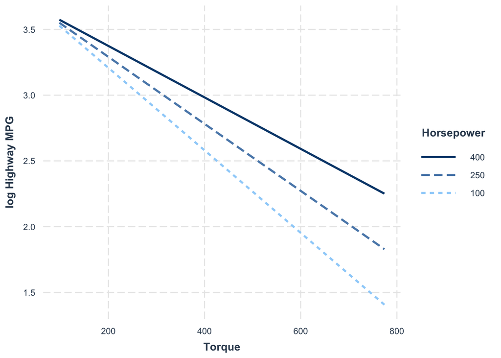

```r
# Plot interaction
interact_plot(lm2, pred = `EI:ES_torque`, modx = `EI:ES_horsepower`,
  modx.values = c(100, 250, 400),
  at = list(`ID:Year` = 2010),
  x.label = "Torque",
  y.label = "log Highway MPG",
  legend.main = "Horsepower",
  data = data1
)
```

From the interaction plot, we see a negative relationship between torque and log highway MPG. Also, Higher horsepower has higher log highway MPG compared to those with lower horsepower. In addition, log highway MPG drops more steeply as torque increases for lower horsepower.

### f

```r
# Create dummy variable year
library(dplyr)
data <- data1 %>%
  mutate(
    y2010 = ifelse(`ID:Year`== 2010, 1, 0),
    y2011 = ifelse(`ID:Year` == 2011, 1, 0),
    y2012 = ifelse(`ID:Year` == 2012, 1, 0)
  )
```

```r
#Construct X and Y
X <- cbind(1, data1$`EI:ES_torque`,
           data$y2010,
           data$y2011,
           data$y2012,
           data1$`EI:ES_horsepower`,
           data1$`Dim:Height`,
           data1$`Dim:Length`,
           data1$`Dim:Width`
           )

Y <- data1$log_highway_mpg
```

```r
# Solve for beta_hat
beta_hat <- solve(t(X) %*% X) %*% t(X) %*% Y
beta_hat
```

```
               [,1]
 [1,]  3.506922e+00
 [2,] -2.294331e-03
 [3,] -2.181247e-02
 [4,] -2.430359e-03
 [5,]  4.011528e-02
 [6,]  9.238126e-04
 [7,]  4.049897e-04
 [8,]  3.475207e-05
 [9,] -8.722295e-05
```

We see the beta hat we get equal to what we get in part d.